# HAD7002H Assignment2

Junya Uchida

2025-06-02

```r
library(tidyverse)
library(causaldata)
library(ltmle)
library(SuperLearner)
library(glmnet)
library(xgboost)
library(tmle)
```

# Question 1

## (a)

```r
dead <-     c(0, 0, 0, 0, 1, 1, 1, 1)
received <- c(0, 1, 1, 0, 0, 1, 1, 0)
assigned <- c(0, 1, 0, 1, 0, 1, 0, 1)
counts <- c(11514, 9663, 0, 2385, 74, 12, 0, 34)
dead <- rep(dead, times = counts)
received <- rep(received, times = counts)
assigned <- rep(assigned, times = counts)
data <- data.frame(dead, received, assigned)
```

Since the intention-to-treat (ITT) principle requires computation of causal effects estimate based on the treatment assignment instead of treatment received, the denominator of mortality risk for assigned and unassigned group is sum of assigned patients and unassigned patients, respectively.

```r
nb <- 10
nobs <- nrow(data)
mort_risk_diff <- rep(NA, nb)
set.seed(1)
for(i in 1:nb) {
  bootidx <- sample(c(1:nobs), size = nobs, replace = TRUE)
  boot_data <- data[bootidx, ]

  death_as1 <- boot_data %>%
  filter(dead == 1 & assigned == 1)
  death_as0 <- boot_data %>%
  filter(dead == 1 & assigned == 0)

  mort_as1 <- nrow(death_as1)/nrow(boot_data[boot_data$assigned == 1, ])
  mort_as0 <- nrow(death_as0)/nrow(boot_data[boot_data$assigned == 0, ])

  mort_risk_diff[i] <- mort_as1 - mort_as0
  if (i %% 1 == 0)
    print(i)
}
```

```
## [1] 1
## [1] 2
## [1] 3
## [1] 4
## [1] 5
## [1] 6
## [1] 7
## [1] 8
## [1] 9
## [1] 10
```

```r
mean(mort_risk_diff)
```

```
## [1] -0.002736425
```

```r
mean(mort_risk_diff) + qnorm(c(0.025,0.975)) * sd(mort_risk_diff)
```

```
## [1] -0.003924136 -0.001548714
```

Therefore, the mortality risk difference between treatment assigned group versus treatment unassigned group is -0.002736425 (95%CI: -0.003924136, -0.001548714). Since this does not cross 0, there is statistically significant evidence that the treatment reduces mortality based on the ITT effect estimate.

The assumption required for identification of the ITT effect include exchangeability where the randomization is independent of any confounders and preserved randomization by estimating the effect by assigned group not by treatment received.

In terms of the validity of these assumptions, the exchangeablity is likely ensured because the treatment (vitamin supplement) or placebo was randomly assigned, blocking the path from unmeasured confounders. As for whether randomization is preserved or not, it is valid since I estimated the effect (mortality risk difference) based on the treatment assignment instead of treatment received. In ITT analysis, if there are many non-adherent participants, the effect estimate would be attracted to null.

## (b)

```r
nb <- 10
nobs <- nrow(data)
IV_estimate_cov <- rep(NA, nb)
set.seed(1)
for(i in 1:nb) {
  bootidx <- sample(c(1:nobs), size = nobs, replace = TRUE)
  boot_data <- data[bootidx, ]

  num_z1 <- mean(boot_data$dead[boot_data$assigned==1])
  num_z0 <- mean(boot_data$dead[boot_data$assigned==0])
  den_a1 <- mean(boot_data$received[boot_data$assigned==1])
  den_a0 <- mean(boot_data$received[boot_data$assigned==0])

  if ((den_a1 - den_a0) !=0){
    IV_estimate_cov[i] <- (num_z1 - num_z0)/(den_a1 - den_a0)
  }
  else {
    IV_estimate_cov[i] <- NA
  }

  if (i %% 1 == 0)
    print(i)
}
```

```
## [1] 1
## [1] 2
## [1] 3
## [1] 4
## [1] 5
## [1] 6
## [1] 7
## [1] 8
## [1] 9
## [1] 10
```

```r
mean(IV_estimate_cov)
```

```
## [1] -0.003413226
```

```r
mean(IV_estimate_cov) + qnorm(c(0.025, 0.975))*sd(IV_estimate_cov)
```

```
## [1] -0.004892316 -0.001934136
```

Using the covariance ratio estimator method, the IV estimate is -0.003413226 (95%CI: -0.004892316, -0.001934136).

```r
nb <- 10
nobs <- nrow(data)
IV_estimate_2stgls <- rep(NA, nb)
set.seed(1)
for(i in 1:nb) {
  bootidx <- sample(c(1:nobs), size = nobs, replace = TRUE)
  boot_data <- data[bootidx, ]

  stg1 <- lm(received ~ assigned, data = boot_data)
  b1forstg2 <- predict(stg1, type = "response")
  stg2 <- lm(dead ~ b1forstg2, data = boot_data)

  IV_estimate_2stgls[i] <- stg2$coef[2]

  if (i %% 1 == 0)
    print(i)
}
```

```
## [1] 1
## [1] 2
## [1] 3
## [1] 4
## [1] 5
## [1] 6
## [1] 7
## [1] 8
## [1] 9
## [1] 10
```

```r
mean(IV_estimate_2stgls)
```

```
## [1] -0.003413226
```

```r
mean(IV_estimate_2stgls) + qnorm(c(0.025, 0.975))*sd(IV_estimate_2stgls)
```

```
## [1] -0.004892316 -0.001934136
```

Using 2-stage least squares method, the IV estimate is -0.003413226 (95%CI: -0.004892316, -0.001934136). Therefore, using either of these two methods, there is statistically significant evidence that receiving treatment decreases the mortality risk among compliers.

The assumptions required for identification of the IV estimand include 1) exchangeability where the assoiation between IV and outcome is not confounded, 2) relevance where the IV is associated with intermediate variable (treatment received), 3) exclusion criteria where there is no direct causal pathway from IV to outcome, and 4) monotonicity where there is no defiers.

As for the exchangeability, this is valid as the treatment was randomly assigned. Relevance is valid since assignment must be related to the treatment actually received (intermediate variable) due to the nature of RCT. Exclusion criteria is likely valid if the trial was double-blinded since knowing who would benefit from the treatment could violate this assumption. Monotonicity is valid since intervention (intervention) was not available for control group.

## (c)

The IV estimand using covariance ratio estimator and the 2-stage least squares methods with 95% bootstrap CI are given above. The computation using the alternative variance calculation is given below.

```r
# covariance ratio estimator method
ratio_altvar_num <- var(data$dead - mean(IV_estimate_cov) * data$received)
ratio_altvar_den <- nrow(data) * var(data$received) * (cor(data$received, data$assigned)^2)
ratio_altsd <- sqrt(ratio_altvar_num/ratio_altvar_den)

list(sd(IV_estimate_cov), ratio_altsd)
```

```
## [[1]]
## [1] 0.0007546517
##
## [[2]]
## [1] 0.001152865
```

```r
# 2-stage least squares method
reg_altvar_num <- var(data$dead - mean(IV_estimate_2stgls) * data$received)
reg_altvar_den <- nrow(data) * var(data$received) * (cor(data$received, data$assigned)^2)
reg_altsd <- sqrt(reg_altvar_num/reg_altvar_den)

list(sd(IV_estimate_2stgls), reg_altsd)
```

```
## [[1]]
## [1] 0.0007546517
##
## [[2]]
## [1] 0.001152865
```

The alternative standard error is greater than bootstrap standard error.

# Question 2

```r
data2 <- nhefs_complete
data2 <- data2 %>%
  mutate(tax71_binary = case_when(tax71 < 1.25 ~ 0,
                                  tax71 >= 1.25 ~ 1))
names(data2)
```

```
##  [1] "seqn"              "qsmk"              "death"
##  [4] "yrdth"             "modth"             "dadth"
##  [7] "sbp"               "dbp"               "sex"
## [10] "age"               "race"              "income"
## [13] "marital"           "school"            "education"
## [16] "ht"                "wt71"              "wt82"
## [19] "wt82_71"           "birthplace"        "smokeintensity"
## [22] "smkintensity82_71" "smokeyrs"          "asthma"
## [25] "bronch"            "tb"                "hf"
## [28] "hbp"               "pepticulcer"       "colitis"
## [31] "hepatitis"         "chroniccough"      "hayfever"
## [34] "diabetes"          "polio"             "tumor"
## [37] "nervousbreak"      "alcoholpy"         "alcoholfreq"
## [40] "alcoholtype"       "alcoholhowmuch"    "pica"
## [43] "headache"          "otherpain"         "weakheart"
## [46] "allergies"         "nerves"            "lackpep"
## [49] "hbpmed"            "boweltrouble"      "wtloss"
## [52] "infection"         "active"            "exercise"
## [55] "birthcontrol"      "pregnancies"       "cholesterol"
## [58] "hightax82"         "price71"           "price82"
## [61] "tax71"             "tax82"             "price71_82"
## [64] "tax71_82"          "id"                "censored"
## [67] "older"             "tax71_binary"
```

```r
data2 %>%
  select(tax71, tax71_binary, qsmk, wt82_71) %>%
  summarize(across(everything(), ~sum(is.na(.))))
```

```
## # A tibble: 1 × 4
##   tax71 tax71_binary  qsmk wt82_71
##   <int>        <int> <int>   <int>
## 1    90           90     0       0
```

## (a)

The strength of instrument refers to the relevance assumption, which is one of the required assumption for instrumental variable. Therefore, the strength of an instrument refers to how strongly the instrument (tax in the state of residence in 1971 dichotomized at $1.25) is associated with the treatment (smoking cessation). In order to quantify this strength, one way to confirm the association is to fit a regression model with the independent variable of an instrument and the response of the treatment to confirm the association. Also, correlation coefficient is another indicator of association.

## (b)

```r
nb <- 10
nobs2 <- nrow(data2)
IV_estimate_cov2 <- rep(NA, nb)
set.seed(1)
for(i in 1:nb) {
  bootidx <- sample(c(1:nobs2), size = nobs2, replace = TRUE)
  boot_data2 <- data2[bootidx, ] %>%
    drop_na(tax71_binary)

  num_z1_2 <- mean(boot_data2$wt82_71[boot_data2$tax71_binary==1])
  num_z0_2 <- mean(boot_data2$wt82_71[boot_data2$tax71_binary==0])
  den_a1_2 <- mean(boot_data2$qsmk[boot_data2$tax71_binary==1])
  den_a0_2 <- mean(boot_data2$qsmk[boot_data2$tax71_binary==0])

  if ((den_a1_2 - den_a0_2) !=0) {
    IV_estimate_cov2[i] <- (num_z1_2 - num_z0_2)/(den_a1_2 -  den_a0_2)
  }
  else {
    IV_estimate_cov2[i] <- NA
  }

  if (i %% 1 == 0)
    print(i)
}
```

```
## [1] 1
## [1] 2
## [1] 3
## [1] 4
## [1] 5
## [1] 6
## [1] 7
## [1] 8
## [1] 9
## [1] 10
```

```r
mean(IV_estimate_cov2)
```

```
## [1] 11.22678
```

```r
mean(IV_estimate_cov2) + qnorm(c(0.025, 0.975)) * sd(IV_estimate_cov2)
```

```
## [1] -34.05643  56.50998
```

```r
ratio_altvar_num2 <- var(data2$wt82_71 - mean(IV_estimate_cov2) * data2$qsmk)
ratio_altvar_den2 <- nrow(data2) * var(data2$qsmk) *
  (cor(data2$qsmk, data2$tax71_binary, use ="complete.obs")^2)
ratio_altsd2 <- sqrt(ratio_altvar_num2/ratio_altvar_den2)

list(
 mean(IV_estimate_cov2),
 mean(IV_estimate_cov2) + qnorm(c(0.025, 0.975)) * sd(IV_estimate_cov2),
 mean(IV_estimate_cov2) + qnorm(c(0.025, 0.975)) * ratio_altsd2
)
```

```
## [[1]]
## [1] 11.22678
##
## [[2]]
## [1] -34.05643  56.50998
##
## [[3]]
## [1] -75.44728  97.90083
```

## (c)

```r
nb <- 10
nobs2 <- nrow(data2)
IV_estimate_2stgls2 <- rep(NA, nb)
set.seed(1)
for(i in 1:nb) {
  bootidx <- sample(c(1:nobs2), size = nobs2, replace = TRUE)
  boot_data2 <- data2[bootidx, ] %>%
    drop_na(tax71_binary)

  stg1_2 <- lm(qsmk ~ tax71_binary, data = boot_data2)
  b1forstg2_2 <- predict(stg1_2, type ="response")
  stg2_2 <- lm(wt82_71 ~ b1forstg2_2, data = boot_data2)

  IV_estimate_2stgls2[i] <- stg2_2$coef[2]

  if(i %% 1 ==0)
    print(i)
}
```

```
## [1] 1
## [1] 2
## [1] 3
## [1] 4
## [1] 5
## [1] 6
## [1] 7
## [1] 8
## [1] 9
## [1] 10
```

```r
reg_altvar_num2 <- var(data2$wt82_71 - mean(IV_estimate_2stgls2) * data2$qsmk)
reg_altvar_den2 <- nrow(data2) * var(data2$qsmk) *
  (cor(data2$qsmk, data2$tax71_binary, use ="complete.obs")^2)
reg_altsd2 <- sqrt(reg_altvar_num2/reg_altvar_den2)

list(
 mean(IV_estimate_2stgls2),
 mean(IV_estimate_2stgls2) + qnorm(c(0.025, 0.975)) * sd(IV_estimate_2stgls2),
 mean(IV_estimate_2stgls2) + qnorm(c(0.025, 0.975)) * reg_altsd2
)
```

```
## [[1]]
## [1] 11.22678
##
## [[2]]
## [1] -34.05643  56.50998
##
## [[3]]
## [1] -75.44728  97.90083
```

By using tax in the state of residence in 1971 as an instrumental variable, the IV estimate was 11.22678 and the 95%CI is (-34.05643, 56.50998) computed with bootstrap standard error and (-75.44728, 97.90083) computed with an alternative standard error. Based on this, there is no evidence that smoking cessation affects weight gain. These estimated values are the same as the ones computed with ratio-type IV estimator above.

# Question 3

```r
data2 %>%
  select(exercise) %>%
  table()
```

```
## exercise
##   0   1   2
## 300 661 605
```

```r
data3 <- data2 %>%
  select(qsmk, sex, race, age, school, smokeintensity,
         smokeyrs, exercise, active, wt71, wt82_71) %>%
  mutate(exercise = case_when(exercise %in% c(0, 1) ~ 1,
                              exercise == 2 ~ 0))
```

## (a)

```r
data3_noY <- data3 %>%
  select(!wt82_71)

# outcome model
set.seed(123)
out_fit <-SuperLearner(Y = data3$wt82_71,
                       X = data3_noY,
                       cvControl = list(V = 3),
                       SL.library = c("SL.glm",
                                      "SL.glmnet",
                                      "SL.xgboost"),
                       method = "method.NNLS",
                       family = "gaussian")

data3$init.pred <- predict(out_fit, newdata = data3_noY, type = "response")$pred
summary(data3$init.pred)
```

```
##        V1
##  Min.   :-6.9156
##  1st Qu.: 0.8462
##  Median : 2.7463
##  Mean   : 2.6383
##  3rd Qu.: 4.5237
##  Max.   :10.7902
```

```r
# treated
data3_noY$exercise <- 1
data3$Pred.Y1 <- predict(out_fit, newdata = data3_noY, type = "response")$pred
summary(data3$Pred.Y1)
```

```
##        V1
##  Min.   :-7.1954
##  1st Qu.: 0.8042
##  Median : 2.6744
##  Mean   : 2.5559
##  3rd Qu.: 4.4862
##  Max.   :10.5745
```

```r
#control
data3_noY$exercise <- 0
data3$Pred.Y0 <- predict(out_fit, newdata = data3_noY, type ="response")$pred
summary(data3$Pred.Y0)
```

```
##        V1
##  Min.   :-6.9156
##  1st Qu.: 0.9776
##  Median : 2.8932
##  Mean   : 2.7709
##  3rd Qu.: 4.6931
##  Max.   :10.9253
```

```r
# Compute initial treatment effect estimate
data3$Pred.TE <- data3$Pred.Y1 - data3$Pred.Y0
summary(data3$Pred.TE)
```

```
##        V1
##  Min.   :-0.7196
##  1st Qu.:-0.2840
##  Median :-0.2068
##  Mean   :-0.2150
##  3rd Qu.:-0.1424
##  Max.   : 0.4167
```

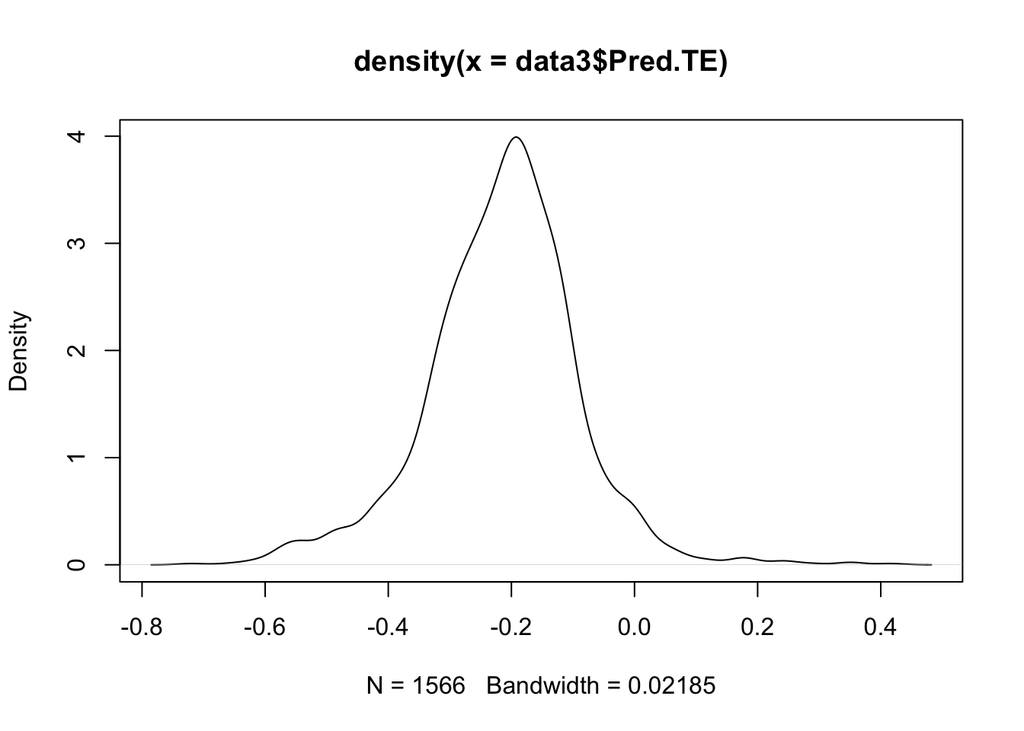

```r
plot(density(data3$Pred.TE))
```

```r
# Treatment model
set.seed(124)
covariates <- data3 %>%
  select(-c(exercise, wt82_71, init.pred, Pred.Y1, Pred.Y0, Pred.TE))

# treatment model
PS_fit <- SuperLearner(Y = data3$exercise,
                       X = covariates,
                       cvControl = list(V = 3),
                       SL.library = c("SL.glm",
                                      "SL.glmnet",
                                      "SL.xgboost"),
                       method = "method.CC_nloglik",
                       family = "binomial")
saveRDS(PS_fit, file = "SL_TMLE_PS")

PS_fit <- readRDS(file = "SL_TMLE_PS")
data3$PS_SL <- predict(PS_fit, type = "response")$pred
tapply(data3$PS_SL, data3$exercise, summary)
```

```
## $`0`
##    Min. 1st Qu.  Median    Mean 3rd Qu.    Max.
## 0.07182 0.42244 0.59373 0.54682 0.68053 0.86396
##
## $`1`
##    Min. 1st Qu.  Median    Mean 3rd Qu.    Max.
##  0.1403  0.5950  0.6764  0.6557  0.7435  0.8835
```

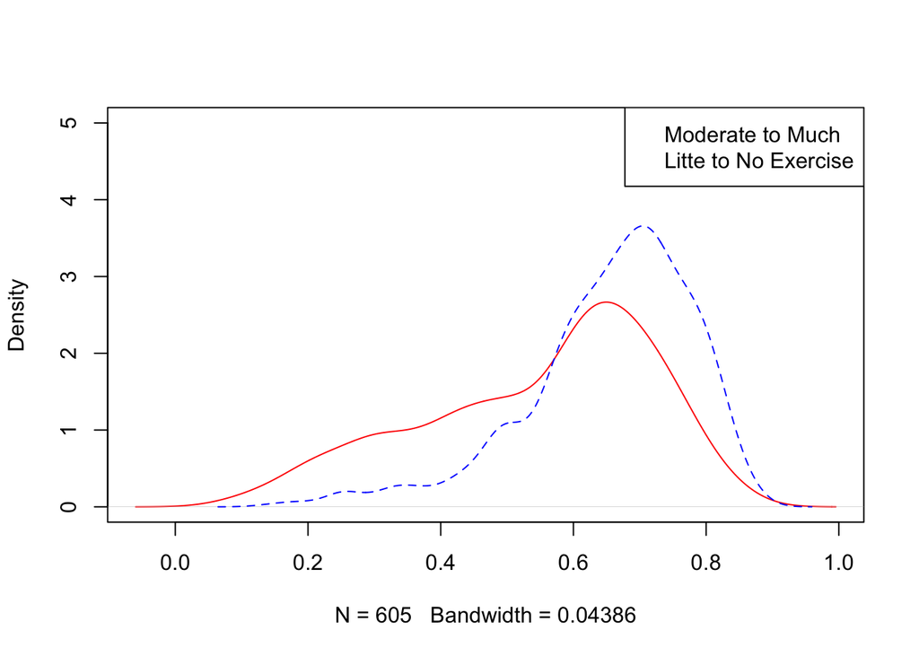

```r
plot(density(data3$PS_SL[data3$exercise == 0]), col = "red", main="", ylim = c(0, 5))
lines(density(data3$PS_SL[data3$exercise==1]), col = "blue", lty =2)
legend("topright", c("Moderate to Much", "Litte to No Exercise"))
```

```r
# clever covariate H
data3$H.A1L <- (data3$exercise)/data3$PS_SL
data3$H.A0L <- (1-data3$exercise)/(1-data3$PS_SL)
data3$H.AL <- data3$H.A1L - data3$H.A0L
summary(data3$H.AL)
```

```
##        V1
##  Min.   :-7.350749
##  1st Qu.:-1.994027
##  Median : 1.302976
##  Mean   :-0.001479
##  3rd Qu.: 1.540219
##  Max.   : 7.129137
```

```r
tapply(data3$H.AL, data3$exercise, summary)
```

```
## $`0`
##    Min. 1st Qu.  Median    Mean 3rd Qu.    Max.
##  -7.351  -3.130  -2.461  -2.573  -1.731  -1.077
##
## $`1`
##    Min. 1st Qu.  Median    Mean 3rd Qu.    Max.
##   1.132   1.345   1.478   1.617   1.681   7.129
```

```r
# fluctuation parameter
eps_mod <- glm(wt82_71 ~ -1 + H.AL + offset(init.pred),
               family = "gaussian",
               data = data3)
epsilon <- coef(eps_mod)
epsilon # very small value
```

```
##        H.AL
## 0.007825654
```

```r
# update
data3$Pred.Y1.update1 <- data3$Pred.Y1 + epsilon * data3$H.AL
data3$Pred.Y0.update1 <- data3$Pred.Y0 + epsilon * data3$H.AL
summary(data3$Pred.Y1.update1)
```

```
##        V1
##  Min.   :-7.2089
##  1st Qu.: 0.8022
##  Median : 2.6830
##  Mean   : 2.5559
##  3rd Qu.: 4.4790
##  Max.   :10.5852
```

```r
summary(data3$Pred.Y0.update1)
```

```
##        V1
##  Min.   :-6.9292
##  1st Qu.: 0.9676
##  Median : 2.8993
##  Mean   : 2.7709
##  3rd Qu.: 4.6991
##  Max.   :10.9360
```

```r
data3$update.Pred <- ifelse(data3$exercise ==1,
                            data3$Pred.Y1.update1,
                            data3$Pred.Y0.update1)
eps_mod1 <- glm(wt82_71 ~ -1 + H.AL + offset(update.Pred),
                family = "gaussian",
                data = data3)
epsilon1 <- coef(eps_mod1)
epsilon1 # further smaller
```

```
##          H.AL
## -9.939423e-17
```

```r
# Estimate ATE
data3$Pred.Y1.update2 <- data3$Pred.Y1.update1 + epsilon1 + data3$H.AL
data3$Pred.Y0.update2 <- data3$Pred.Y0.update1 + epsilon1 + data3$H.AL
summary(data3$Pred.Y1.update2)
```

```
##        V1
##  Min.   :-8.94036
##  1st Qu.:-0.09856
##  Median : 2.70691
##  Mean   : 2.55438
##  3rd Qu.: 5.40132
##  Max.   :11.95409
```

```r
summary(data3$Pred.Y0.update2)
```

```
##        V1
##  Min.   :-8.6606
##  1st Qu.: 0.0964
##  Median : 2.9239
##  Mean   : 2.7694
##  3rd Qu.: 5.6384
##  Max.   :12.3048
```

```r
# RD
ATE <- data3$Pred.Y1.update2 - data3$Pred.Y0.update2
summary(ATE)
```

```
##        V1
##  Min.   :-0.7196
##  1st Qu.:-0.2840
##  Median :-0.2068
##  Mean   :-0.2150
##  3rd Qu.:-0.1424
##  Max.   : 0.4167
```

```r
## estimate of causal effect
ATE.TMLE <- mean(ATE)
ci.estimate <- function(data3a = data3){
  EY1 <- mean(data3a$Pred.Y1.update2, na.rm = TRUE)
  EY0 <- mean(data3a$Pred.Y0.update2, na.rm = TRUE)

  D1 <- data3a$exercise/data3a$PS_SL*
    (data3a$wt82_71 - data3a$Pred.Y1.update2) +
    data3a$Pred.Y1.update2 - EY1
  D0 <- (1 - data3a$exercise)/(1 - data3a$PS_SL)*
    (data3a$wt82_71 - data3a$Pred.Y0.update2) +
    data3a$Pred.Y0.update2 - EY0
  EIC <- D1 - D0
  # ATE variance
  n <- nrow(data3a)
  varHat.IC <- var(EIC, na.rm = TRUE)/n
  # ATE 95% CI
  ATE.TMLE.CI <- c(ATE.TMLE - 1.96*sqrt(varHat.IC),
                   ATE.TMLE + 1.96*sqrt(varHat.IC))
  return(ATE.TMLE.CI)
}

print(c(mean(ATE), ci.estimate(data = data3)))
```

```
## [1] -0.2150084 -1.0094633  0.5794464
```

The ATE is -0.2150084 (95%CI: -1.0094633, 0.5794464). Since the 95%CI crosses 0, there is not statistically significant evidence that moderate to much exercise can change the weight gain. Also, since $\hat{e}<0.0001$, it can be considered that TMLE achieved convergence.

## (b)

```r
library(tmle)
SL.library = c("SL.glm",
               "SL.glmnet",
               "SL.xgboost")

tmle.fit <- tmle(Y = data3$wt82_71,
                   A = data3$exercise,
                   W = covariates,
                   family = "gaussian",
                   V.Q = 3, #outcome model
                   V.g = 3, #treatment model
                   Q.SL.library = c("SL.glm",
                                   "SL.glmnet",
                                   "SL.xgboost"),
                   g.SL.library = c("SL.glm",
                                    "SL.glmnet",
                                    "SL.xgboost"))

saveRDS(tmle.fit, file = "SL_TMLE")
tmle.fit <- readRDS(file = "SL_TMLE")
summary(tmle.fit)
```

```
##  Initial estimation of Q
##   Procedure: cv-SuperLearner, ensemble
##   Model:
##       Y ~  SL.glm_All + SL.glmnet_All + SL.xgboost_All
##
##   Coefficients:
##        SL.glm_All    0.3072593
##     SL.glmnet_All    0.584957
##    SL.xgboost_All    0.1077836
##
##   Cross-validated R squared :  0.1109
##
##  Estimation of g (treatment mechanism)
##   Procedure: SuperLearner, ensemble
##   Model:
##       A ~  SL.glm_All + SL.glmnet_All + SL.xgboost_All
##
##   Coefficients:
##        SL.glm_All    0.703407
##     SL.glmnet_All    0.296593
##    SL.xgboost_All    0
##
##  Estimation of g.Z (intermediate variable assignment mechanism)
##   Procedure: No intermediate variable
##
##  Estimation of g.Delta (missingness mechanism)
##   Procedure: No missingness, ensemble
##
##  Bounds on g: (0.0172, 1)
##
##  Bounds on g for ATT/ATC: (0.0172, 0.9828)
##
##  Marginal Mean under Treatment (EY1)
##    Parameter Estimate:  2.5954
##    Estimated Variance:  0.06851
##               p-value:  <2e-16
##     95% Conf Interval:  (2.0824, 3.1085)
##
##  Marginal Mean under Comparator (EY0)
##    Parameter Estimate:  2.8061
##    Estimated Variance:  0.1085
##               p-value:  <2e-16
##     95% Conf Interval:  (2.1605, 3.4517)
##
##  Additive Effect
##    Parameter Estimate:  -0.21063
##    Estimated Variance:  0.16781
##               p-value:  0.60714
##     95% Conf Interval:  (-1.0135, 0.59227)
##
##  Additive Effect among the Treated
##    Parameter Estimate:  -0.31268
##    Estimated Variance:  0.16224
##               p-value:  0.43758
##     95% Conf Interval:  (-1.1021, 0.47677)
##
##  Additive Effect among the Controls
##    Parameter Estimate:  -0.091204
##    Estimated Variance:  0.24677
##               p-value:  0.85433
##     95% Conf Interval:  (-1.0648, 0.88243)
```

Using `tmle` package and the same SuperLearner package in the question 3(a), the ATE is -0.21063 (95%CI: -1.0135, 0.59227). Since the 95%CI crosses 0, there is not statistically significant evidence that exercise can change the weight gain.

## (c)

For the first TMLE step using SuperLearner, the estimated ATE was -0.2150084 (95%CI: -1.0094633, 0.5794464) while the second fit using `tlme`package yielded -0.21063 (95%CI: -1.0135, 0.59227). Therefore, although the latter one has slightly wider 95%CI, there was not huge difference in terms of the precision of the estimates between the two.

# Question 4

```r
sim.r <-function(samplesize = 500){
 set.seed(123)
 expit <-function(x){exp(x)/(1+exp (x))}

 #covariates
 L1 <- runif(n=samplesize, 0, 1)
 L2 <- runif(n=samplesize, 0, 1)
 U <- rbinom(n=samplesize, size = 1, prob = 0.4)

 #treatment
 Aprob <- expit(3*L1 - 3*L2 + 3*U)
 A <- rbinom(n=samplesize, size =1, prob=Aprob)

 #outcome
 Yprob <- expit(3*A + 3*L1 - 3*L2 + 3*U)
 Y <- rbinom(n = samplesize, size = 1, prob = Yprob)
 dat <- cbind(L1, L2, U, A, Y)
 dat <- data.frame(dat)
 return(dat)
}
simdat <- sim.r(samplesize = 500)

head(simdat)
```

```
##          L1         L2 U A Y
## 1 0.2875775 0.35360608 0 1 1
## 2 0.7883051 0.36644144 0 0 1
## 3 0.4089769 0.28710013 0 1 1
## 4 0.8830174 0.07997291 1 1 1
## 5 0.9404673 0.36545427 1 1 1
## 6 0.0455565 0.17801381 0 0 1
```

## (a)

```r
nb <- 10
nobs <- nrow(simdat)
rr_est <- rep(NA, nb)
set.seed(123)
for(i in 1:nb){
  bootidx <- sample(c(1:nobs), size = nobs, replace = TRUE)
  bootdat <- simdat[bootidx, ]

  # treatment model
  simdat_tm <- glm(A ~ L1 + L2, data = bootdat, family = binomial("logit"))
  simdat_ps <- predict(simdat_tm, type = "response")

  # iptw
  bootdat <- bootdat %>%
    mutate(iptw = if_else(A == 1, 1/simdat_ps, 1/(1-simdat_ps)))

  # split by assignment
  bootdat1 <- bootdat[bootdat$A == 1, ]
  bootdat0 <- bootdat[bootdat$A == 0, ]

  # compute weighted average
  EY1 <- sum(bootdat1$Y * bootdat1$iptw)/sum(bootdat1$iptw)
  EY0 <- sum(bootdat0$Y * bootdat0$iptw)/sum(bootdat0$iptw)

  rr_est[i] <- EY1/EY0
  if (i %% 1 == 0)
    print(i)
}
```

```
## [1] 1
## [1] 2
## [1] 3
## [1] 4
## [1] 5
## [1] 6
## [1] 7
## [1] 8
## [1] 9
## [1] 10
```

```r
mean(rr_est)
```

```
## [1] 1.796261
```

```r
mean(rr_est) + qnorm(c(0.025, 0.975)) * sd(rr_est)
```

```
## [1] 1.536126 2.056396
```

Assuming $U$ is unmeasured and given measured covariates $L1$ and $L2$, the IPTW estimator for risk ratio (RR) and bootstrap confidence interval is 1.796261 (95%CI: 1.536126, 2.056396). Since the 95%CI does not cross 1, there is a statistically significant association between treatment $A$ and outcome $Y$.

## (b)

E-value can be computed with fairly simple computation as follows:

$$\text{E-value}= RR +\sqrt{RR ×(RR-1)},$$

where $RR = RR^{obs}_{AY}$, which was computed in the Question 4(a). Therefore, the E-value can be given as follows:

```r
RR_obs <- mean(rr_est)
E_value <- RR_obs + sqrt(RR_obs * (RR_obs -1))
E_value
```

```
## [1] 2.992209
```

The computed E-value is 2.992209. E-value represents the minimum strength of association, on the RR, that unmeasured confounder would have to have with the treatment and outcome to fully explain away a specific association between treatment and outcome, conditional on the measured covariates. This value represents the magnitude of the unmeasured confounder that would be required to produce confounding bias equal to the observed treatment-outcome association.

## (c)

```r
nb <- 10
nobs <- nrow(simdat)
rr_all <- rep(NA, nb)
set.seed(123)
for(i in 1:nb){
  bootidx <- sample(c(1:nobs), size = nobs, replace = TRUE)
  bootdat <- simdat[bootidx, ]

  simdat_tmall <- glm(A ~ U + L1 + L2, data = bootdat, family = binomial("logit"))
  simdat_psall <- predict(simdat_tmall, type = "response")

  bootdat <- bootdat %>%
    mutate(iptw = if_else(A == 1, 1/simdat_psall, 1/(1-simdat_psall)))

  bootdat1 <- bootdat[bootdat$A== 1, ]
  bootdat0 <- bootdat[bootdat$A== 0, ]

  EY1 <- sum(bootdat1$Y * bootdat1$iptw) / sum(bootdat1$iptw)
  EY0 <- sum(bootdat0$Y * bootdat0$iptw) / sum(bootdat0$iptw)

  rr_all[i] <-  EY1/EY0

  if (i %% 1 == 0)
    print(i)
}
```

```
## [1] 1
## [1] 2
## [1] 3
## [1] 4
## [1] 5
## [1] 6
## [1] 7
## [1] 8
## [1] 9
## [1] 10
```

```r
mean(rr_all)
```

```
## [1] 1.381878
```

```r
mean(rr_all) + qnorm(c(0.025, 0.975)) * sd(rr_all)
```

```
## [1] 1.201644 1.562113
```

### Compared to the RR estimate without $U$ (a)

The IPTW estimator for RR without $U$ was 1.796261 (95%CI: 1.536126, 2.056396), which indicates that without $U$, observed treatment-outcome association would be stronger than the IPTW estimator for RR given both measured and unmeasured confounders. However, both estimates are statistically significant as 95% CIs do not cross 1.

### Compared to the E-value (b)

Since the IPTW RR estimator adjusted for both measured and unmeasured confounders remained statistically significant, the magnitude of unmeasured confounder was not strong enough to explain away the observed treatment-outcome association. If no other unmeasured confounders exist, it can be concluded that there is likely an association between treatment $A$ and outcome $Y$.